# Recent College Graduates: Quick Facts

Author

Kristin Butcher and Aryan Safi

## Definition

A **Recent College Graduate (RCG)** is a person who is **age 21–26** and holds a **bachelor’s degree or higher** (`AGE %in% 21:26` and `EDUC >= 111` in IPUMS CPS). This captures people near the usual age of bachelor’s-degree completion and the first several years afterward.

A **Young Less-Bachelor’s (YLB)** person is **age 18–25** with **less than a bachelor’s degree** (`AGE %in% 18:25` and `EDUC < 111`). This is the age-peer comparison group for RCGs who did not complete a four-year degree; several questions below add a YLB series alongside RCG and overall figures.

All shares, rates, means, and medians use the IPUMS basic monthly person weight (`WTFINL`). The sample is the regular monthly basic CPS from January 1994 through the latest extract month, with the ASEC supplement excluded.

```r
csv_path <- here("exploring_new_entrants", "data", "CPS", "cps_rcg.csv.gz")

cps <- fread(csv_path)

cps[, `:=`(
  date     = make_date(YEAR, MONTH, 1L),
  is_rcg   = AGE >= 21 & AGE <= 26 & EDUC >= 111,
  is_ylb   = AGE >= 18 & AGE <= 25 & EDUC < 111,
  is_lf    = LABFORCE == 2,
  is_emp   = EMPSTAT %in% c(10L, 12L),
  is_unemp = EMPSTAT %in% c(20L, 21L, 22L)
)]
cps[, is_ne_re := is_unemp & WHYUNEMP %in% c(5L, 6L)]
cps[, is_ne    := is_unemp & WHYUNEMP == 6L]
cps[, is_re    := is_unemp & WHYUNEMP == 5L]
cps[, dur_wks  := fifelse(is_unemp & DURUNEMP < 999,
                          as.numeric(DURUNEMP), NA_real_)]

latest_month    <- cps[, max(date)]
latest_12_start <- latest_month - months(11)
format_window   <- paste0(format(latest_12_start, "%b %Y"),
                          " – ", format(latest_month, "%b %Y"))

# ── Monthly aggregates for shares / rates ───────────────────────────────────
monthly <- cps[, .(
  rcg_unemp_w   = sum(WTFINL * (is_rcg & is_unemp), na.rm = TRUE),
  rcg_lf_w      = sum(WTFINL * (is_rcg & is_lf),    na.rm = TRUE),
  ylb_unemp_w   = sum(WTFINL * (is_ylb & is_unemp), na.rm = TRUE),
  ylb_lf_w      = sum(WTFINL * (is_ylb & is_lf),    na.rm = TRUE),
  total_unemp_w = sum(WTFINL * is_unemp,            na.rm = TRUE),
  total_lf_w    = sum(WTFINL * is_lf,               na.rm = TRUE),
  ne_re_w       = sum(WTFINL * is_ne_re,            na.rm = TRUE),
  ne_w          = sum(WTFINL * is_ne,               na.rm = TRUE),
  re_w          = sum(WTFINL * is_re,               na.rm = TRUE),
  nere_nonrcg_w = sum(WTFINL * (is_ne_re & !is_rcg), na.rm = TRUE)
), by = date]
setorder(monthly, date)
monthly[, `:=`(
  rcg_unemp_rate     = 100 * rcg_unemp_w / rcg_lf_w,
  ylb_unemp_rate     = 100 * ylb_unemp_w / ylb_lf_w,
  overall_unemp_rate = 100 * total_unemp_w / total_lf_w,
  rcg_share_unemp    = 100 * rcg_unemp_w / total_unemp_w,
  rcg_share_lf       = 100 * rcg_lf_w    / total_lf_w,
  ylb_share_unemp    = 100 * ylb_unemp_w / total_unemp_w,
  ylb_share_lf       = 100 * ylb_lf_w    / total_lf_w,
  ne_re_share        = 100 * ne_re_w     / total_unemp_w,
  ne_share           = 100 * ne_w        / total_unemp_w,
  re_share           = 100 * re_w        / total_unemp_w,
  ne_re_lf_share     = 100 * ne_re_w     / total_lf_w,
  nere_nonrcg_share_unemp = 100 * nere_nonrcg_w / total_unemp_w,
  nere_nonrcg_share_lf    = 100 * nere_nonrcg_w / total_lf_w,
  rcg_lf_millions    = rcg_lf_w / 1e6
)]

# ── Monthly aggregates for duration ──────────────────────────────────────────
unemp_dt    <- cps[is_unemp & !is.na(dur_wks)]
monthly_dur <- unemp_dt[, .(
  rcg_mean       = weighted_mean(dur_wks[is_rcg], WTFINL[is_rcg]),
  rcg_median     = weighted_median(dur_wks[is_rcg], WTFINL[is_rcg]),
  ylb_mean       = weighted_mean(dur_wks[is_ylb], WTFINL[is_ylb]),
  ylb_median     = weighted_median(dur_wks[is_ylb], WTFINL[is_ylb]),
  overall_mean   = weighted_mean(dur_wks, WTFINL),
  overall_median = weighted_median(dur_wks, WTFINL)
), by = date]
setorder(monthly_dur, date)

# ── Window-summary helpers (for the headline tables) ────────────────────────
window_label_12  <- paste0("Latest 12 months (", format_window, ")")
window_label_all <- paste0("Pooled Jan 1994–", format(latest_month, "%b %Y"))

in_window_12 <- function(d) d >= latest_12_start & d <= latest_month

# ── Per-question time-series panel helper (for share/rate plots) ────────────
rate_panel <- function(dt, col, title, color,
                       y_label = "Percent", y_suffix = "%") {
  d <- copy(dt)
  d[, .v   := get(col)]
  d[, .ma  := roll_mean12(.v)]
  d[, .med := roll_median12(.v)]
  p <- ggplot(d, aes(x = date)) +
    geom_line(aes(y = .v),   color = color, alpha = 0.25, linewidth = 0.4) +
    geom_line(aes(y = .ma),  color = color, linewidth = 1.0, alpha = 0.9) +
    geom_line(aes(y = .med), color = color, linewidth = 0.9, alpha = 0.9,
              linetype = "dashed") +
    scale_y_continuous(labels = \(x) paste0(x, y_suffix)) +
    scale_x_date(date_breaks = "5 years", date_labels = "%Y") +
    labs(title = title,
         subtitle = "Monthly (light); 12-mo rolling mean (solid); 12-mo rolling median (dashed). NBER recessions shaded.",
         y = y_label, x = NULL)
  add_recessions(p)
}

# ── Two-series comparison panel (e.g., RCG vs Overall) ──────────────────────
compare_panel <- function(dt, cols, labels, colors, title, y_label = "Percent",
                          y_suffix = "%") {
  d <- copy(dt)[, c("date", cols), with = FALSE]
  d_long <- melt(d, id.vars = "date", measure.vars = cols,
                 variable.name = "series", value.name = "value")
  d_long[, series := factor(series, levels = cols, labels = labels)]
  d_long[, ma := roll_mean12(value), by = series]

  p <- ggplot(d_long, aes(x = date, color = series)) +
    geom_line(aes(y = value), alpha = 0.25, linewidth = 0.4) +
    geom_line(aes(y = ma),    linewidth = 1.0, alpha = 0.9) +
    scale_color_manual(values = setNames(colors, labels)) +
    scale_y_continuous(labels = \(x) paste0(x, y_suffix)) +
    scale_x_date(date_breaks = "5 years", date_labels = "%Y") +
    labs(title = title,
         subtitle = "Monthly (light); 12-month rolling mean (bold). NBER recessions shaded.",
         y = y_label, x = NULL)
  add_recessions(p)
}
```

The most recent month in the extract is **April 2026**. Below, *latest 12 months* means **May 2025 – Apr 2026** and *pooled* means **January 1994–April 2026**.

## Q1. What percentage of recent college graduates are unemployed?

Unemployed RCGs divided by RCGs in the labor force, weighted by `WTFINL`.

```r
q1_value <- function(dt) {
  d <- dt[is_rcg & is_lf]
  d[, sum(WTFINL * is_unemp, na.rm = TRUE) / sum(WTFINL, na.rm = TRUE)]
}

q1_tbl <- data.table(
  Window = c(window_label_12, window_label_all),
  `RCG unemployment rate` = c(
    fmt_pct(100 * q1_value(cps[in_window_12(date)])),
    fmt_pct(100 * q1_value(cps))
  )
)

q1_tbl |> gt() |> style_gt()
```

| Window | RCG unemployment rate |
| --- | --- |
| Latest 12 months (May 2025 – Apr 2026) | 6.0% |
| Pooled Jan 1994–Apr 2026 | 5.1% |

**RCG only**

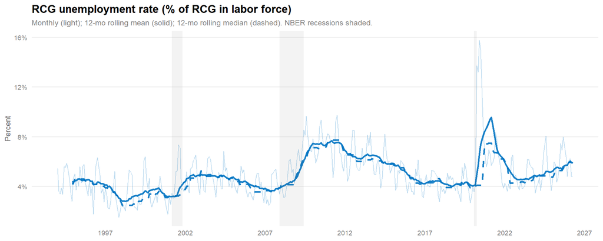

```r
rate_panel(monthly, "rcg_unemp_rate",
           "RCG unemployment rate (% of RCG in labor force)", jco[1])
```

**RCG vs Overall**

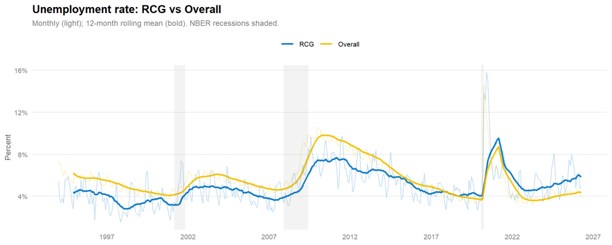

```r
compare_panel(
  monthly,
  cols   = c("rcg_unemp_rate", "overall_unemp_rate"),
  labels = c("RCG", "Overall"),
  colors = c(rcg_col, overall_col),
  title  = "Unemployment rate: RCG vs Overall"
)
```

**RCG vs YLB vs Overall**

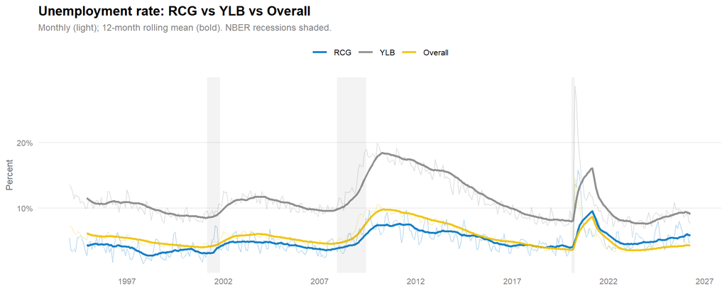

```r
compare_panel(
  monthly,
  cols   = c("rcg_unemp_rate", "ylb_unemp_rate", "overall_unemp_rate"),
  labels = c("RCG", "YLB", "Overall"),
  colors = c(rcg_col, ylb_col, overall_col),
  title  = "Unemployment rate: RCG vs YLB vs Overall"
)
```

## Q2. What percentage of the unemployed are recent college graduates?

```r
q2_value <- function(dt) {
  d <- dt[is_unemp == TRUE]
  d[, sum(WTFINL * is_rcg, na.rm = TRUE) / sum(WTFINL, na.rm = TRUE)]
}
q2_ylb_value <- function(dt) {
  d <- dt[is_unemp == TRUE]
  d[, sum(WTFINL * is_ylb, na.rm = TRUE) / sum(WTFINL, na.rm = TRUE)]
}

q2_tbl <- data.table(
  Window = c(window_label_12, window_label_all),
  `RCG share of unemployed` = c(
    fmt_pct(100 * q2_value(cps[in_window_12(date)])),
    fmt_pct(100 * q2_value(cps))
  ),
  `YLB share of unemployed` = c(
    fmt_pct(100 * q2_ylb_value(cps[in_window_12(date)])),
    fmt_pct(100 * q2_ylb_value(cps))
  )
)

q2_tbl |> gt() |> style_gt()
```

| Window | RCG share of unemployed | YLB share of unemployed |
| --- | --- | --- |
| Latest 12 months (May 2025 – Apr 2026) | 5.1% | 22.6% |
| Pooled Jan 1994–Apr 2026 | 2.8% | 24.7% |

**RCG share of unemployed**

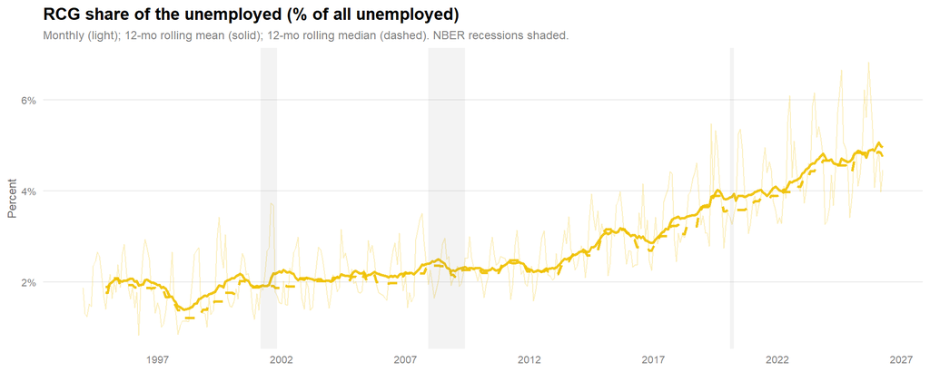

```r
rate_panel(monthly, "rcg_share_unemp",
           "RCG share of the unemployed (% of all unemployed)", jco[2])
```

**Share of unemployed vs Share of LF**

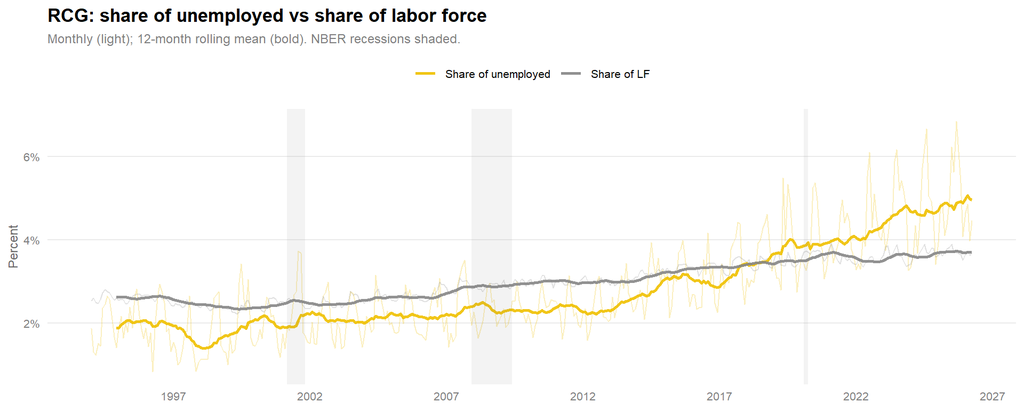

```r
compare_panel(
  monthly,
  cols   = c("rcg_share_unemp", "rcg_share_lf"),
  labels = c("Share of unemployed", "Share of LF"),
  colors = c(jco[2], jco[3]),
  title  = "RCG: share of unemployed vs share of labor force"
)
```

When the “share of unemployed” line sits above the “share of LF” line, RCGs are *over*-represented in the unemployed pool relative to their presence in the labor force, and vice versa.

**YLB: share of unemployed vs share of LF**

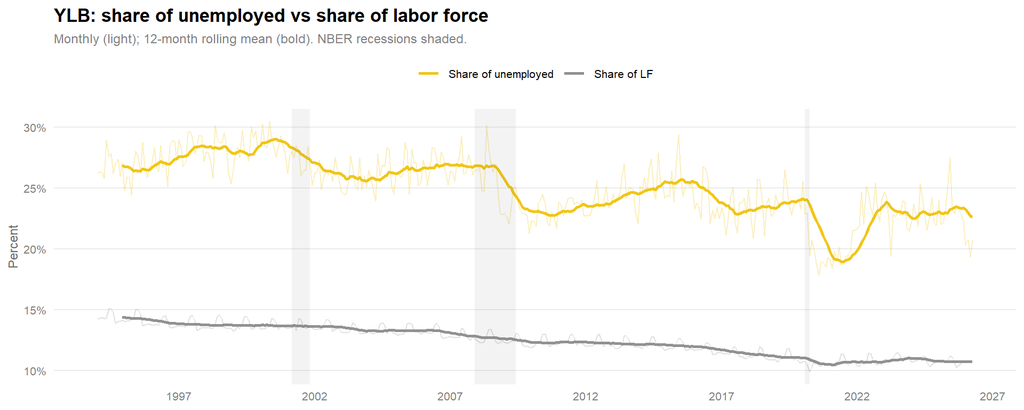

```r
compare_panel(
  monthly,
  cols   = c("ylb_share_unemp", "ylb_share_lf"),
  labels = c("Share of unemployed", "Share of LF"),
  colors = c(jco[2], jco[3]),
  title  = "YLB: share of unemployed vs share of labor force"
)
```

The same reading applies to YLB: when the “share of unemployed” line sits above the “share of LF” line, young workers without a bachelor’s are over-represented among the unemployed relative to their share of the labor force.

**Non-RCG entrants: share of unemployed vs LF**

This isolates **New Entrants + Reentrants who are *not* RCG** (`WHYUNEMP %in% 5:6 & !is_rcg`) and asks how much of the unemployed pool — and of the labor force — they make up. It strips the recent-graduate slice out of the entry categories so the line reflects everyone *else* entering or re-entering the job market.

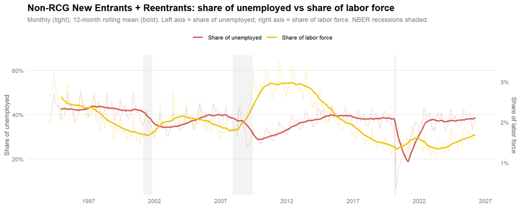

```r
# Share-of-unemployed (~15-25%) and share-of-labor-force (~1-2%) differ by
# roughly the unemployment rate, so the labor-force series is rescaled onto a
# secondary right-hand axis (sec_axis divides the scaling factor back out).
sf_q2 <- mean(monthly$nere_nonrcg_share_unemp, na.rm = TRUE) /
         mean(monthly$nere_nonrcg_share_lf, na.rm = TRUE)

q2_ov_long <- rbindlist(list(
  monthly[, .(date, series = "Share of unemployed",
              value = nere_nonrcg_share_unemp)],
  monthly[, .(date, series = "Share of labor force",
              value = nere_nonrcg_share_lf * sf_q2)]
))
q2_ov_long[, series := factor(series,
                              levels = c("Share of unemployed", "Share of labor force"))]
q2_ov_long[, ma := roll_mean12(value), by = series]

q2_ov_cols <- c("Share of unemployed"  = jco[4],
                "Share of labor force" = jco[2])

p_q2_ov <- ggplot(q2_ov_long, aes(x = date, color = series)) +
  geom_line(aes(y = value), alpha = 0.25, linewidth = 0.4) +
  geom_line(aes(y = ma),    linewidth = 1.0, alpha = 0.9) +
  scale_color_manual(values = q2_ov_cols) +
  scale_y_continuous(
    name     = "Share of unemployed",
    labels   = \(x) paste0(x, "%"),
    sec.axis = sec_axis(~ . / sf_q2, name = "Share of labor force",
                        labels = \(x) paste0(x, "%"))
  ) +
  scale_x_date(date_breaks = "5 years", date_labels = "%Y") +
  labs(title = "Non-RCG New Entrants + Reentrants: share of unemployed vs share of labor force",
       subtitle = "Monthly (light); 12-month rolling mean (bold). Left axis = share of unemployed; right axis = share of labor force. NBER recessions shaded.",
       x = NULL)
add_recessions(p_q2_ov)
```

## Q3. What percentage of the labor force are recent college graduates?

```r
q3_value <- function(dt) {
  d <- dt[is_lf == TRUE]
  d[, sum(WTFINL * is_rcg, na.rm = TRUE) / sum(WTFINL, na.rm = TRUE)]
}

q3_tbl <- data.table(
  Window = c(window_label_12, window_label_all),
  `RCG share of labor force` = c(
    fmt_pct(100 * q3_value(cps[in_window_12(date)])),
    fmt_pct(100 * q3_value(cps))
  )
)

q3_tbl |> gt() |> style_gt()
```

| Window | RCG share of labor force |
| --- | --- |
| Latest 12 months (May 2025 – Apr 2026) | 3.7% |
| Pooled Jan 1994–Apr 2026 | 3.0% |

**Share of LF**

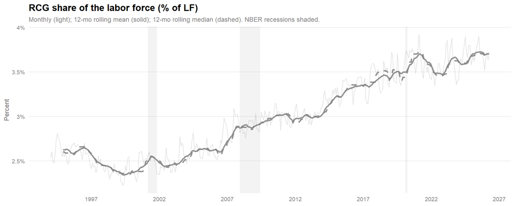

```r
rate_panel(monthly, "rcg_share_lf",
           "RCG share of the labor force (% of LF)", jco[3])
```

**Counts (millions)**

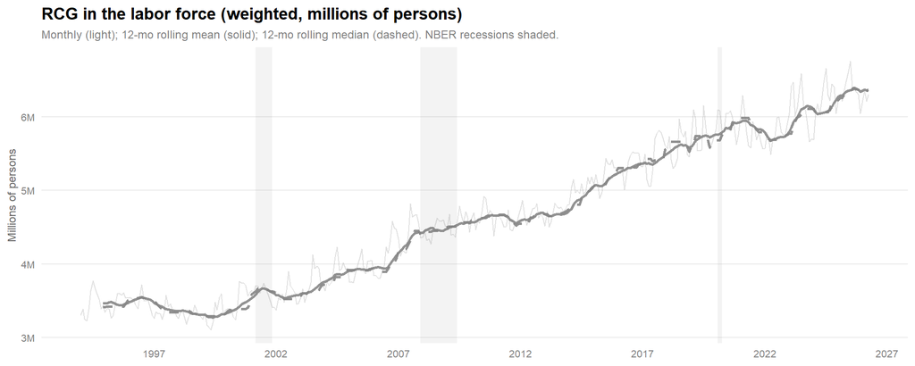

```r
rate_panel(monthly, "rcg_lf_millions",
           "RCG in the labor force (weighted, millions of persons)", jco[3],
           y_label = "Millions of persons", y_suffix = "M")
```

## Q4. What share of the unemployed — and of the labor force — are New Entrants or Reentrants?

```r
q4_value <- function(dt) {
  d <- dt[is_unemp == TRUE]
  d[, sum(WTFINL * is_ne_re, na.rm = TRUE) / sum(WTFINL, na.rm = TRUE)]
}
ne_re_lf_value <- function(dt) {
  d <- dt[is_lf == TRUE]
  d[, sum(WTFINL * is_ne_re, na.rm = TRUE) / sum(WTFINL, na.rm = TRUE)]
}

q4_tbl <- data.table(
  Window = c(window_label_12, window_label_all),
  `Share of unemployed` = c(
    fmt_pct(100 * q4_value(cps[in_window_12(date)])),
    fmt_pct(100 * q4_value(cps))
  ),
  `Share of labor force` = c(
    fmt_pct(100 * ne_re_lf_value(cps[in_window_12(date)])),
    fmt_pct(100 * ne_re_lf_value(cps))
  )
)

q4_tbl |> gt() |> style_gt()
```

| Window | Share of unemployed | Share of labor force |
| --- | --- | --- |
| Latest 12 months (May 2025 – Apr 2026) | 42.0% | 1.9% |
| Pooled Jan 1994–Apr 2026 | 37.8% | 2.1% |

**Overlay: unemployed vs labor force**

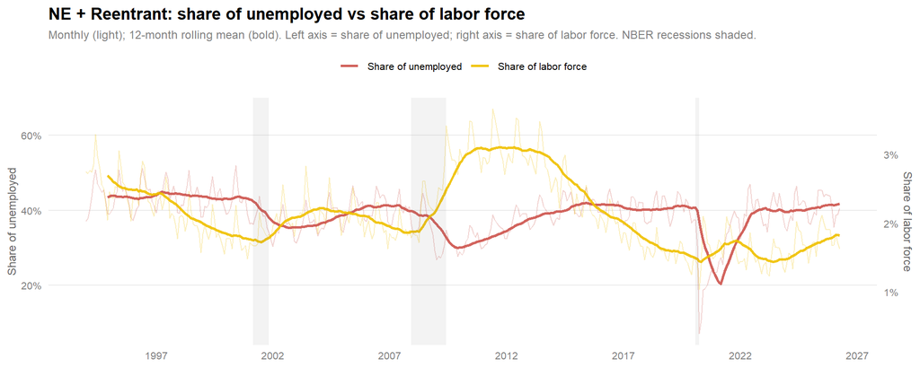

```r
# Share-of-unemployed (~15-25%) and share-of-labor-force (~1-2%) differ by
# roughly the unemployment rate, so the labor-force series is rescaled onto a
# secondary right-hand axis (sec_axis divides the scaling factor back out).
sf <- mean(monthly$ne_re_share, na.rm = TRUE) /
      mean(monthly$ne_re_lf_share, na.rm = TRUE)

ov_long <- rbindlist(list(
  monthly[, .(date, series = "Share of unemployed",  value = ne_re_share)],
  monthly[, .(date, series = "Share of labor force", value = ne_re_lf_share * sf)]
))
ov_long[, series := factor(series,
                           levels = c("Share of unemployed", "Share of labor force"))]
ov_long[, ma := roll_mean12(value), by = series]

ov_cols <- c("Share of unemployed"  = jco[4],
             "Share of labor force" = jco[2])

p_ov <- ggplot(ov_long, aes(x = date, color = series)) +
  geom_line(aes(y = value), alpha = 0.25, linewidth = 0.4) +
  geom_line(aes(y = ma),    linewidth = 1.0, alpha = 0.9) +
  scale_color_manual(values = ov_cols) +
  scale_y_continuous(
    name     = "Share of unemployed",
    labels   = \(x) paste0(x, "%"),
    sec.axis = sec_axis(~ . / sf, name = "Share of labor force",
                        labels = \(x) paste0(x, "%"))
  ) +
  scale_x_date(date_breaks = "5 years", date_labels = "%Y") +
  labs(title = "NE + Reentrant: share of unemployed vs share of labor force",
       subtitle = "Monthly (light); 12-month rolling mean (bold). Left axis = share of unemployed; right axis = share of labor force. NBER recessions shaded.",
       x = NULL)
add_recessions(p_ov)
```

**Share of the unemployed**

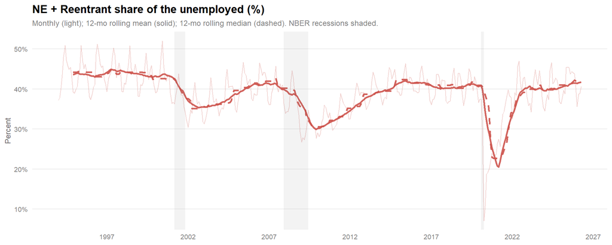

```r
rate_panel(monthly, "ne_re_share",
           "NE + Reentrant share of the unemployed (%)", jco[4])
```

**Share of the labor force**

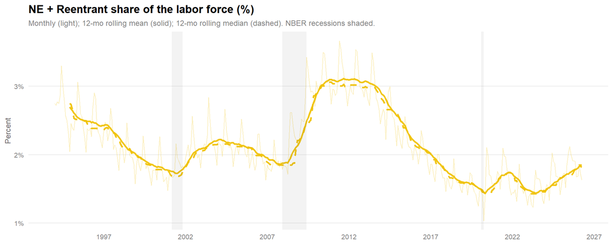

```r
rate_panel(monthly, "ne_re_lf_share",
           "NE + Reentrant share of the labor force (%)", jco[2])
```

**Decomposed (NE vs Reentrant)**

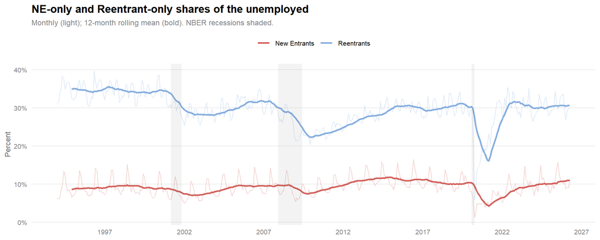

```r
compare_panel(
  monthly,
  cols   = c("ne_share", "re_share"),
  labels = c("New Entrants", "Reentrants"),
  colors = c(jco[4], jco[5]),
  title  = "NE-only and Reentrant-only shares of the unemployed"
)
```

## Q5. How long are recent college graduates unemployed compared to everyone else?

Weighted **mean** and **median** weeks unemployed (`DURUNEMP`) for unemployed RCGs and for all unemployed people.

```r
q5_value <- function(dt) {
  rcg <- dt[is_unemp & is_rcg]
  ylb <- dt[is_unemp & is_ylb]
  all <- dt[is_unemp == TRUE]
  data.table(
    `RCG mean (weeks)`       = weighted_mean(rcg$dur_wks,  rcg$WTFINL),
    `RCG median (weeks)`     = weighted_median(rcg$dur_wks, rcg$WTFINL),
    `YLB mean (weeks)`       = weighted_mean(ylb$dur_wks,  ylb$WTFINL),
    `YLB median (weeks)`     = weighted_median(ylb$dur_wks, ylb$WTFINL),
    `Overall mean (weeks)`   = weighted_mean(all$dur_wks,   all$WTFINL),
    `Overall median (weeks)` = weighted_median(all$dur_wks, all$WTFINL)
  )
}

q5_tbl <- rbindlist(list(
  cbind(data.table(Window = window_label_12),  q5_value(cps[in_window_12(date)])),
  cbind(data.table(Window = window_label_all), q5_value(cps))
))

q5_tbl |>
  gt() |>
  fmt_number(columns = where(is.numeric), decimals = 1) |>
  style_gt()
```

| Window | RCG mean (weeks) | RCG median (weeks) | YLB mean (weeks) | YLB median (weeks) | Overall mean (weeks) | Overall median (weeks) |
| --- | --- | --- | --- | --- | --- | --- |
| Latest 12 months (May 2025 – Apr 2026) | 19.8 | 9.0 | 19.1 | 8.0 | 21.9 | 10.0 |
| Pooled Jan 1994–Apr 2026 | 16.4 | 8.0 | 17.6 | 8.0 | 22.3 | 10.0 |

**Mean weeks**

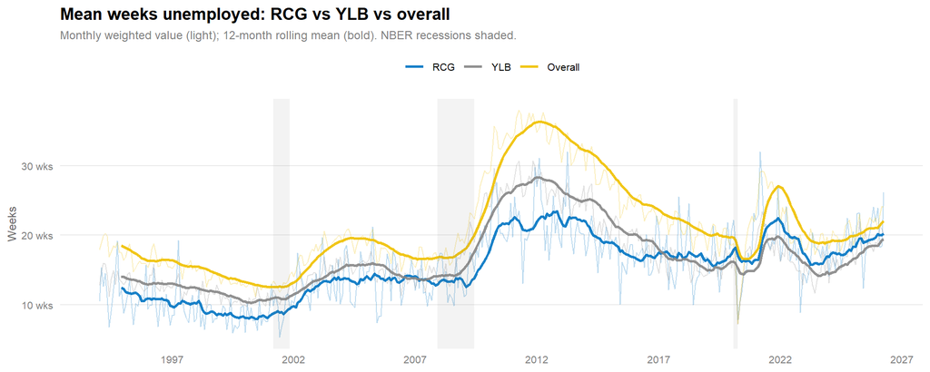

```r
make_dur_panel(dur_long_mean, "Mean weeks unemployed: RCG vs YLB vs overall")
```

**Median weeks**

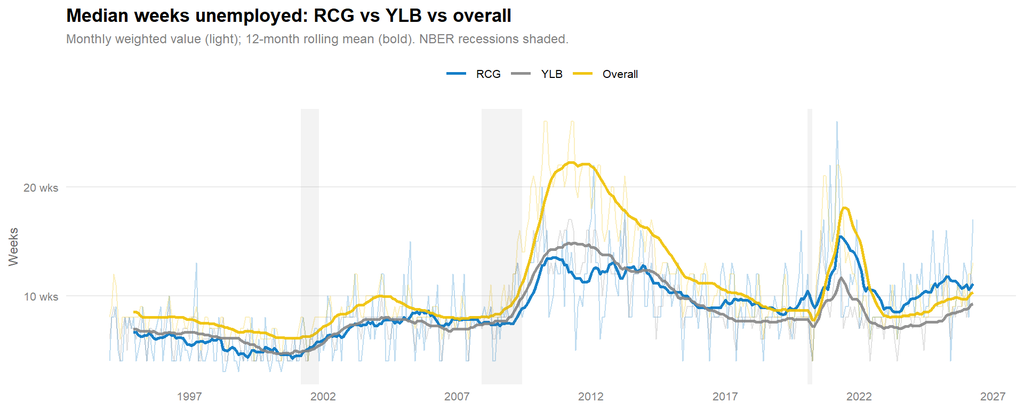

```r
make_dur_panel(dur_long_med, "Median weeks unemployed: RCG vs YLB vs overall")
```

## Q6. When unemployed RCGs are asked *why*, what do they say?

Q4 asked what share of *all* unemployed people are New Entrants or Reentrants. This question conditions on being unemployed and crosstabs **RCG status** against the CPS reason-for-unemployment (`WHYUNEMP`). Each column is a distribution over reasons that **sums to 100% within that group**, so the table reads as: *of unemployed RCGs, what percent give each reason?* — and the same for non-RCGs, for comparison.

A new entrant has **never held a full-time job**; a reentrant has worked before but was out of the labor force just prior to looking again. For a 21–26-year-old with a fresh bachelor’s degree, “new entrant” is the answer that most directly describes someone entering the job market for the first time after school.

```r
why_levels <- c(1L, 2L, 3L, 4L, 5L, 6L)
why_labels <- c("Temporary layoff",        # WHYUNEMP 1: job loser – on layoff
                "Permanent job loser",     # WHYUNEMP 2: other job loser
                "Completed temp job",      # WHYUNEMP 3: temporary job ended
                "Job leaver",              # WHYUNEMP 4
                "Reentrant",               # WHYUNEMP 5
                "New entrant")             # WHYUNEMP 6

# Weighted distribution over WHYUNEMP reasons within a group of the unemployed.
# Denominator = unemployed in the group with a valid reason code, so the
# returned vector of percentages sums to 100.
reason_share <- function(dt, rcg_flag) {
  d   <- dt[is_unemp & is_rcg == rcg_flag & WHYUNEMP %in% why_levels]
  tot <- d[, sum(WTFINL, na.rm = TRUE)]
  vapply(why_levels, function(k)
    100 * d[WHYUNEMP == k, sum(WTFINL, na.rm = TRUE)] / tot,
    numeric(1))
}

# Same distribution, but for the unemployed in an arbitrary group flag column
# (e.g. "is_ylb"). Denominator = that group's unemployed with a valid reason.
reason_share_col <- function(dt, col) {
  d   <- dt[is_unemp & get(col) == TRUE & WHYUNEMP %in% why_levels]
  tot <- d[, sum(WTFINL, na.rm = TRUE)]
  vapply(why_levels, function(k)
    100 * d[WHYUNEMP == k, sum(WTFINL, na.rm = TRUE)] / tot,
    numeric(1))
}
```

```r
q6_12  <- list(rcg = reason_share(cps[in_window_12(date)], TRUE),
               non = reason_share(cps[in_window_12(date)], FALSE),
               ylb = reason_share_col(cps[in_window_12(date)], "is_ylb"))
q6_all <- list(rcg = reason_share(cps, TRUE),
               non = reason_share(cps, FALSE),
               ylb = reason_share_col(cps, "is_ylb"))

q6_tbl <- data.table(
  Reason             = why_labels,
  `RCG (12mo)`       = q6_12$rcg,
  `Non-RCG (12mo)`   = q6_12$non,
  `YLB (12mo)`       = q6_12$ylb,
  `RCG (pooled)`     = q6_all$rcg,
  `Non-RCG (pooled)` = q6_all$non,
  `YLB (pooled)`     = q6_all$ylb
)

q6_tbl |>
  gt() |>
  fmt_number(columns = where(is.numeric), decimals = 1, pattern = "{x}%") |>
  tab_spanner(label = window_label_12,
              columns = c(`RCG (12mo)`, `Non-RCG (12mo)`, `YLB (12mo)`)) |>
  tab_spanner(label = window_label_all,
              columns = c(`RCG (pooled)`, `Non-RCG (pooled)`, `YLB (pooled)`)) |>
  cols_label(
    `RCG (12mo)` = "RCG", `Non-RCG (12mo)` = "Non-RCG", `YLB (12mo)` = "YLB",
    `RCG (pooled)` = "RCG", `Non-RCG (pooled)` = "Non-RCG", `YLB (pooled)` = "YLB"
  ) |>
  style_gt()
```

| Reason | Latest 12 months (May 2025 – Apr 2026) RCG | Latest 12 months (May 2025 – Apr 2026) Non-RCG | Latest 12 months (May 2025 – Apr 2026) YLB | Pooled Jan 1994–Apr 2026 RCG | Pooled Jan 1994–Apr 2026 Non-RCG | Pooled Jan 1994–Apr 2026 YLB |
| --- | --- | --- | --- | --- | --- | --- |
| Temporary layoff | 4.6% | 12.8% | 7.8% | 7.4% | 14.3% | 8.9% |
| Permanent job loser | 12.5% | 26.7% | 14.3% | 13.2% | 29.1% | 17.0% |
| Completed temp job | 5.7% | 8.6% | 5.2% | 8.1% | 9.7% | 8.5% |
| Job leaver | 10.8% | 11.3% | 10.8% | 11.6% | 9.8% | 11.3% |
| Reentrant | 47.4% | 29.8% | 38.5% | 45.7% | 28.1% | 38.5% |
| New entrant | 19.0% | 10.9% | 23.4% | 14.1% | 9.1% | 15.8% |

Reading the table: each column answers “of this group’s unemployed, what percent give each reason?” Comparing the **New entrant** and **Reentrant** rows across the RCG and Non-RCG columns shows whether unemployed RCGs are unusually likely to be entering or re-entering the labor force rather than having lost or left a job.

```r
# Monthly reason mix *within RCG unemployed* (denominator = RCG unemployed).
monthly_rcg_reason <- cps[, .(
  rcg_unemp_w = sum(WTFINL * (is_rcg & is_unemp), na.rm = TRUE),
  rcg_ne_w    = sum(WTFINL * (is_rcg & is_ne),    na.rm = TRUE),
  rcg_re_w    = sum(WTFINL * (is_rcg & is_re),    na.rm = TRUE)
), by = date]
setorder(monthly_rcg_reason, date)
monthly_rcg_reason[, `:=`(
  rcg_ne_share    = 100 * rcg_ne_w / rcg_unemp_w,
  rcg_re_share    = 100 * rcg_re_w / rcg_unemp_w,
  rcg_ne_re_share = 100 * (rcg_ne_w + rcg_re_w) / rcg_unemp_w
)]

# Same NE + Reentrant share, but within YLB unemployed (denominator = YLB unemp).
monthly_ylb_reason <- cps[, .(
  ylb_unemp_w = sum(WTFINL * (is_ylb & is_unemp), na.rm = TRUE),
  ylb_ne_w    = sum(WTFINL * (is_ylb & is_ne),    na.rm = TRUE),
  ylb_re_w    = sum(WTFINL * (is_ylb & is_re),    na.rm = TRUE)
), by = date]
setorder(monthly_ylb_reason, date)
monthly_ylb_reason[, ylb_ne_re_share := 100 * (ylb_ne_w + ylb_re_w) / ylb_unemp_w]
```

**NE + Reentrant share of RCG unemployed**

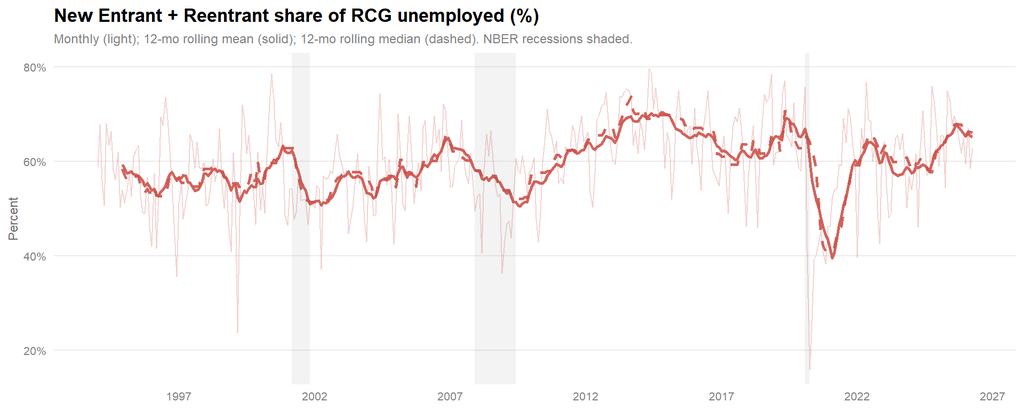

```r
rate_panel(monthly_rcg_reason, "rcg_ne_re_share",
           "New Entrant + Reentrant share of RCG unemployed (%)", jco[4])
```

**Decomposed (NE vs Reentrant)**

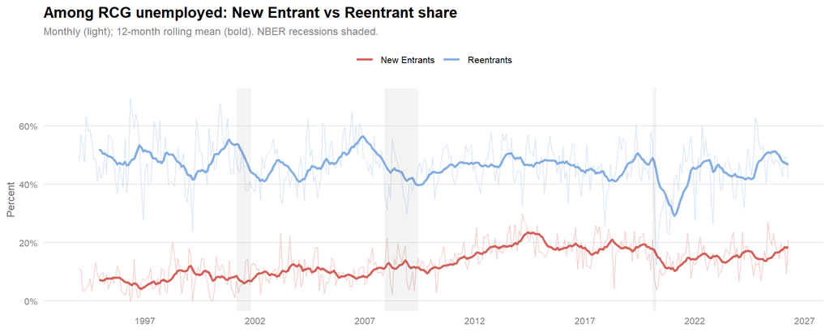

```r
compare_panel(
  monthly_rcg_reason,
  cols   = c("rcg_ne_share", "rcg_re_share"),
  labels = c("New Entrants", "Reentrants"),
  colors = c(jco[4], jco[5]),
  title  = "Among RCG unemployed: New Entrant vs Reentrant share"
)
```

**RCG vs all unemployed**

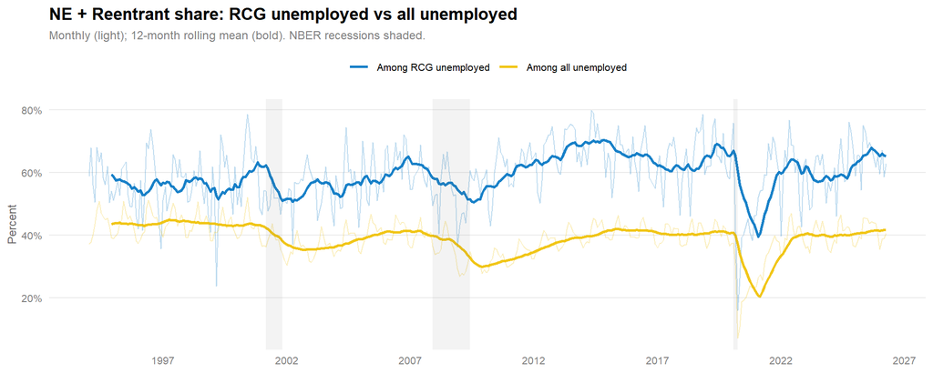

```r
q6_cmp <- merge(
  monthly_rcg_reason[, .(date, rcg_ne_re_share)],
  monthly[, .(date, ne_re_share)],
  by = "date"
)
compare_panel(
  q6_cmp,
  cols   = c("rcg_ne_re_share", "ne_re_share"),
  labels = c("Among RCG unemployed", "Among all unemployed"),
  colors = c(rcg_col, overall_col),
  title  = "NE + Reentrant share: RCG unemployed vs all unemployed"
)
```

**RCG vs all unemployed vs YLB**

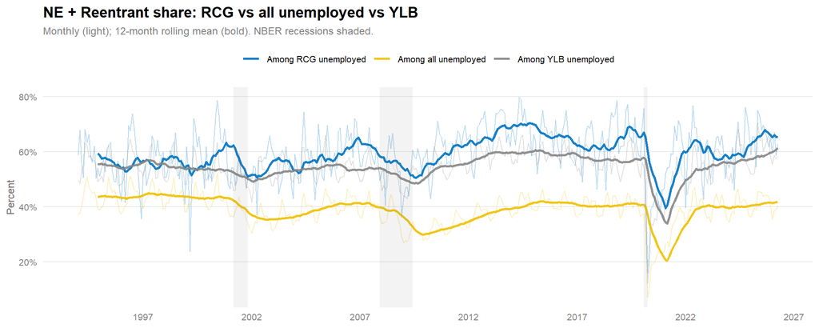

```r
q6_cmp3 <- Reduce(function(x, y) merge(x, y, by = "date"), list(
  monthly_rcg_reason[, .(date, rcg_ne_re_share)],
  monthly[, .(date, ne_re_share)],
  monthly_ylb_reason[, .(date, ylb_ne_re_share)]
))
compare_panel(
  q6_cmp3,
  cols   = c("rcg_ne_re_share", "ne_re_share", "ylb_ne_re_share"),
  labels = c("Among RCG unemployed", "Among all unemployed", "Among YLB unemployed"),
  colors = c(rcg_col, overall_col, ylb_col),
  title  = "NE + Reentrant share: RCG vs all unemployed vs YLB"
)
```

**Note**

Source: IPUMS CPS basic monthly microdata, January 1994–Apr 2026. ASEC samples excluded. All estimates weighted by `WTFINL`.

## Q7. What percentage of New Entrants and Reentrants are recent college graduates?

Q6 conditioned on being an unemployed RCG and asked what reason they give. This question turns the crosstab around: it conditions on the **reason** and asks what share of that group is RCG. The denominators are the unemployed New Entrants (`WHYUNEMP == 6`) and the unemployed Reentrants (`WHYUNEMP == 5`); the numerators are the RCGs within each.

```r
# Share of a reason-group's unemployed that are RCG.
# Denominator = unemployed with that reason; numerator = RCGs among them.
rcg_share_of <- function(dt, flag_col) {
  d <- dt[is_unemp == TRUE & get(flag_col) == TRUE]
  d[, sum(WTFINL * is_rcg, na.rm = TRUE) / sum(WTFINL, na.rm = TRUE)]
}

q7_tbl <- data.table(
  Window = c(window_label_12, window_label_all),
  `RCG share of New Entrants` = c(
    fmt_pct(100 * rcg_share_of(cps[in_window_12(date)], "is_ne")),
    fmt_pct(100 * rcg_share_of(cps, "is_ne"))
  ),
  `RCG share of Reentrants` = c(
    fmt_pct(100 * rcg_share_of(cps[in_window_12(date)], "is_re")),
    fmt_pct(100 * rcg_share_of(cps, "is_re"))
  )
)

q7_tbl |> gt() |> style_gt()
```

| Window | RCG share of New Entrants | RCG share of Reentrants |
| --- | --- | --- |
| Latest 12 months (May 2025 – Apr 2026) | 8.5% | 7.8% |
| Pooled Jan 1994–Apr 2026 | 4.2% | 4.4% |

```r
# Monthly RCG share *within* each reason group (denominator = that group).
monthly_rcg_in_entrants <- cps[, .(
  ne_w        = sum(WTFINL * is_ne,             na.rm = TRUE),
  re_w        = sum(WTFINL * is_re,             na.rm = TRUE),
  rcg_in_ne_w = sum(WTFINL * (is_ne & is_rcg),  na.rm = TRUE),
  rcg_in_re_w = sum(WTFINL * (is_re & is_rcg),  na.rm = TRUE)
), by = date]
setorder(monthly_rcg_in_entrants, date)
monthly_rcg_in_entrants[, `:=`(
  rcg_in_ne_share = 100 * rcg_in_ne_w / ne_w,
  rcg_in_re_share = 100 * rcg_in_re_w / re_w
)]
```

**RCG share of New Entrants**

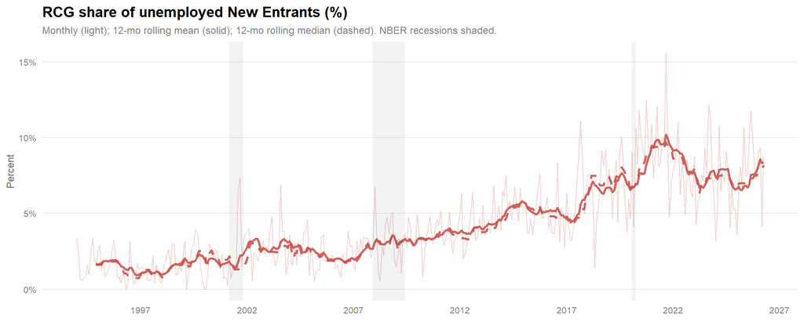

```r
rate_panel(monthly_rcg_in_entrants, "rcg_in_ne_share",
           "RCG share of unemployed New Entrants (%)", jco[4])
```

**RCG share of Reentrants**

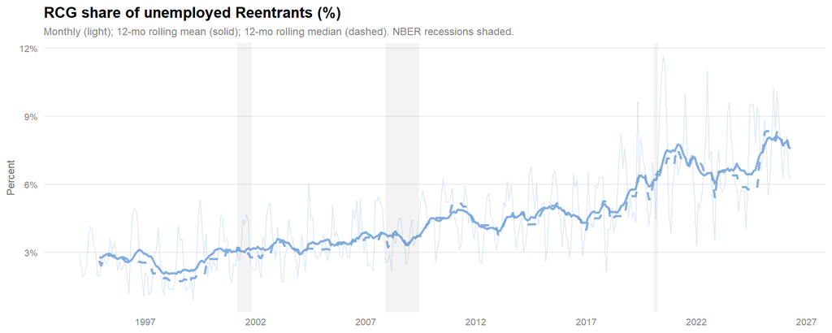

```r
rate_panel(monthly_rcg_in_entrants, "rcg_in_re_share",
           "RCG share of unemployed Reentrants (%)", jco[5])
```

**Both**

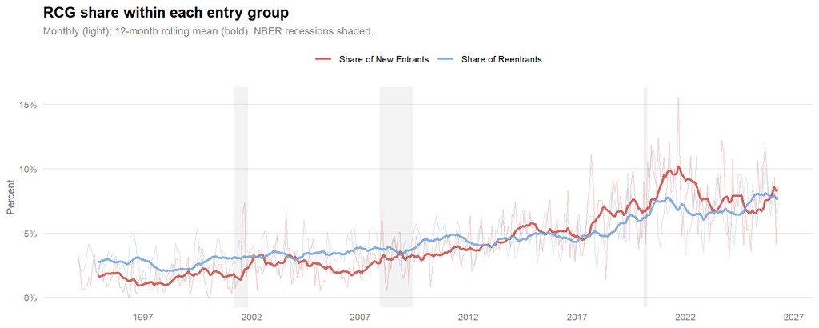

```r
compare_panel(
  monthly_rcg_in_entrants,
  cols   = c("rcg_in_ne_share", "rcg_in_re_share"),
  labels = c("Share of New Entrants", "Share of Reentrants"),
  colors = c(jco[4], jco[5]),
  title  = "RCG share within each entry group"
)
```

**Warning**

These denominators (unemployed New Entrants, unemployed Reentrants) are themselves modest in any single month, so the monthly RCG-share lines are noisy. Lean on the 12-month rolling mean (bold) and the pooled column of the table.

## Q8. How long are people unemployed, by reason for unemployment?

```r
# Weighted mean/median weeks unemployed within each WHYUNEMP reason.
# Rows are reordered to why_levels; reasons absent from the window come back NA.
dur_reason_summary <- function(dt) {
  d <- dt[is_unemp & !is.na(dur_wks) & WHYUNEMP %in% why_levels]
  out <- d[, .(
    mean_wks   = weighted_mean(dur_wks, WTFINL),
    median_wks = weighted_median(dur_wks, WTFINL)
  ), by = WHYUNEMP]
  out[match(why_levels, WHYUNEMP)]
}

s12  <- dur_reason_summary(cps[in_window_12(date)])
sall <- dur_reason_summary(cps)

q8_tbl <- data.table(
  Reason            = why_labels,
  `Mean (12mo)`     = s12$mean_wks,
  `Median (12mo)`   = s12$median_wks,
  `Mean (pooled)`   = sall$mean_wks,
  `Median (pooled)` = sall$median_wks
)

q8_tbl |>
  gt() |>
  fmt_number(columns = where(is.numeric), decimals = 1) |>
  tab_spanner(label = window_label_12,
              columns = c(`Mean (12mo)`, `Median (12mo)`)) |>
  tab_spanner(label = window_label_all,
              columns = c(`Mean (pooled)`, `Median (pooled)`)) |>
  cols_label(
    `Mean (12mo)` = "Mean (wks)", `Median (12mo)` = "Median (wks)",
    `Mean (pooled)` = "Mean (wks)", `Median (pooled)` = "Median (wks)"
  ) |>
  style_gt()
```

| Reason | Latest 12 months (May 2025 – Apr 2026) Mean (wks) | Latest 12 months (May 2025 – Apr 2026) Median (wks) | Pooled Jan 1994–Apr 2026 Mean (wks) | Pooled Jan 1994–Apr 2026 Median (wks) |
| --- | --- | --- | --- | --- |
| Temporary layoff | 7.0 | 4.0 | 8.9 | 5.0 |
| Permanent job loser | 23.1 | 12.0 | 28.5 | 16.0 |
| Completed temp job | 20.6 | 10.0 | 20.8 | 10.0 |
| Job leaver | 19.2 | 9.0 | 17.9 | 8.0 |
| Reentrant | 28.0 | 12.0 | 24.9 | 12.0 |
| New entrant | 22.4 | 9.0 | 21.5 | 8.0 |

```r
# Monthly weighted mean/median weeks unemployed, by WHYUNEMP reason.
monthly_dur_reason <- cps[is_unemp & !is.na(dur_wks) & WHYUNEMP %in% why_levels, .(
  mean_wks   = weighted_mean(dur_wks, WTFINL),
  median_wks = weighted_median(dur_wks, WTFINL)
), by = .(date, WHYUNEMP)]
setorder(monthly_dur_reason, WHYUNEMP, date)
monthly_dur_reason[, reason := factor(WHYUNEMP, levels = why_levels, labels = why_labels)]
monthly_dur_reason[, `:=`(
  mean_ma   = roll_mean12(mean_wks),
  median_ma = roll_mean12(median_wks)
), by = WHYUNEMP]

reason_cols <- setNames(jco, why_labels)

# Six reasons overlaid would be unreadable as raw monthly lines, so only the
# 12-month rolling mean is drawn for each reason.
make_dur_reason_panel <- function(ma_col, title) {
  d <- copy(monthly_dur_reason)
  d[, .y := get(ma_col)]
  p <- ggplot(d, aes(x = date, y = .y, color = reason)) +
    geom_line(linewidth = 0.9, alpha = 0.9) +
    scale_color_manual(values = reason_cols) +
    scale_y_continuous(labels = \(x) paste0(x, " wks")) +
    scale_x_date(date_breaks = "5 years", date_labels = "%Y") +
    labs(title = title,
         subtitle = "12-month rolling mean of the monthly weighted value. NBER recessions shaded.",
         y = "Weeks", x = NULL)
  add_recessions(p)
}
```

**Mean weeks**

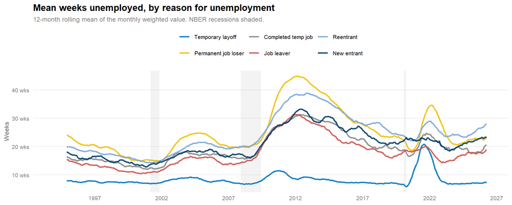

```r
make_dur_reason_panel("mean_ma", "Mean weeks unemployed, by reason for unemployment")
```

**Median weeks**

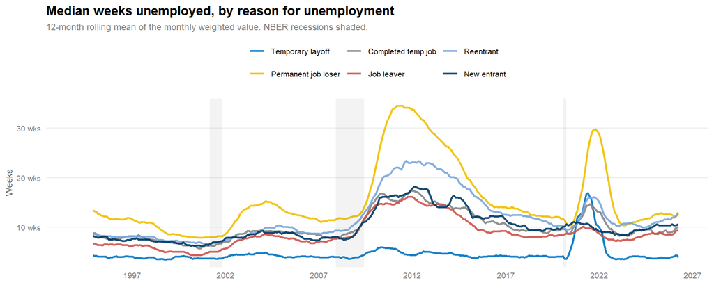

```r
make_dur_reason_panel("median_ma", "Median weeks unemployed, by reason for unemployment")
```

**Note**

Duration here is total weeks unemployed as of the survey, not completed spells, so it is a point-in-time snapshot rather than how long a typical spell ultimately lasts. Permanent job losers and reentrants are the larger reason groups; New Entrants and Job Leavers can be thin in a single month, so lean on the rolling means and the pooled columns.

```r
# Weeks unemployed for the pooled entry group (New Entrants + Reentrants).
# is_ne_re already requires is_unemp, so we only drop missing duration.
monthly_dur_nere <- cps[is_ne_re & !is.na(dur_wks), .(
  mean_wks   = weighted_mean(dur_wks, WTFINL),
  median_wks = weighted_median(dur_wks, WTFINL)
), by = date]
setorder(monthly_dur_nere, date)

# Median-duration levels and gaps for the comparison plot below.
# Levels: overall, RCG, and the pooled entry group. Gaps are differences in
# the monthly weighted medians, so they sit near zero on the same week axis.
dur_levels <- merge(
  monthly_dur[, .(date, overall_median, rcg_median)],
  monthly_dur_nere[, .(date, nere_median = median_wks)],
  by = "date", all = TRUE
)
setorder(dur_levels, date)
dur_levels[, `:=`(
  gap_nere_rcg     = nere_median - rcg_median,
  gap_overall_nere = overall_median - nere_median
)]

# Median weeks unemployed for the complements of the two entry-focused groups:
# non-entrants (job separations only, !is_ne_re) and non-RCG unemployed.
# RCG and the pooled entry group (NE + Reentrant) medians are merged in from
# dur_levels so the plot can show each group against its complement.
monthly_dur_excl <- cps[is_unemp & !is.na(dur_wks), .(
  nonentrant_median = weighted_median(dur_wks[!is_ne_re], WTFINL[!is_ne_re]),
  nonrcg_median     = weighted_median(dur_wks[!is_rcg],   WTFINL[!is_rcg])
), by = date]
monthly_dur_excl <- merge(
  monthly_dur_excl,
  dur_levels[, .(date, rcg_median, nere_median)],
  by = "date", all.x = TRUE
)
setorder(monthly_dur_excl, date)
```

### Entry group only: mean vs median weeks

This pools the two entry reasons from the by-reason plots above — **New Entrants** and **Reentrants** — into a single line and asks how long that combined group sits unemployed. The two lines compare the **mean** (the average spell) against the **median** (the typical, middle spell). When the mean runs above the median, a handful of unusually long searches are pulling the average up while most people’s spells are shorter.

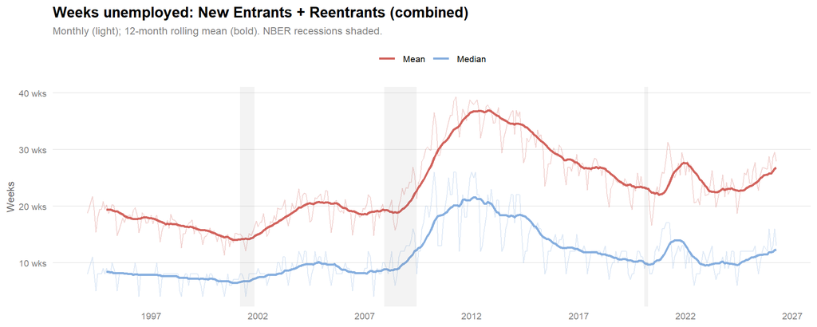

```r
compare_panel(
  monthly_dur_nere,
  cols   = c("mean_wks", "median_wks"),
  labels = c("Mean", "Median"),
  colors = c(jco[4], jco[5]),
  title  = "Weeks unemployed: New Entrants + Reentrants (combined)",
  y_label = "Weeks", y_suffix = " wks"
)
```

### Median weeks: levels and gaps

This puts five **median**-duration series on one chart, all measured in weeks. Three are levels you can read directly: (i) the **overall** median across all unemployed, (ii) the **RCG** median, and (iii) the **New Entrants + Reentrants** median. The other two are gaps that hover near zero on the same axis: (iv) **entry group minus RCG**, which asks whether first-job and returning searchers take longer than recent graduates, and (v) **overall minus entry group**, which shows how much shorter (positive) or longer (negative) entry spells run compared with the typical unemployed worker. A gap above zero means the first group in its label waits longer.

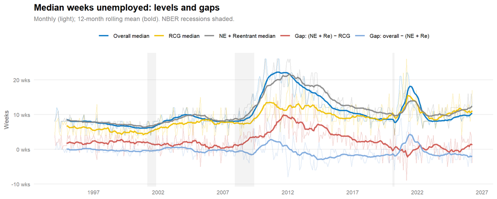

```r
compare_panel(
  dur_levels,
  cols   = c("overall_median", "rcg_median", "nere_median",
             "gap_nere_rcg", "gap_overall_nere"),
  labels = c("Overall median", "RCG median", "NE + Reentrant median",
             "Gap: (NE + Re) − RCG", "Gap: overall − (NE + Re)"),
  colors = jco[1:5],
  title  = "Median weeks unemployed: levels and gaps",
  y_label = "Weeks", y_suffix = " wks"
)
```

**Note**

The gap lines (iv, v) are differences of monthly weighted medians, so they sit near zero against the same week axis as the level lines and can turn negative. As with the other duration plots, the entry-group medians can be thin in a single month — lean on the 12-month rolling mean (bold) rather than the raw monthly line (light).

### Median weeks: non-entrants and non-RCG

The plots above center on the entry categories and on recent graduates. This one pairs each group with its complement so they can be read side by side: the **median** weeks unemployed for (i) **non-entrants** — the unemployed whose reason is a job separation rather than entering or re-entering the labor force (`!is_ne_re`, i.e. `WHYUNEMP %in% 1:4`) — and (ii) **non-RCG** unemployed (`!is_rcg`), alongside (iii) **RCG** and (iv) the pooled **New Entrants + Reentrant** group. All four are weighted medians in weeks, so they read directly off the same axis. The two complement lines (non-entrants, non-RCG) are the large majority of the unemployed, so they track the overall median closely and serve as the baselines the RCG and entry-group durations are measured against.

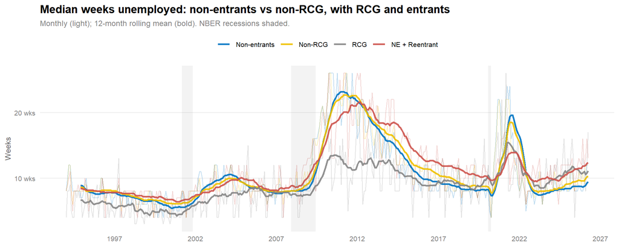

```r
compare_panel(
  monthly_dur_excl,
  cols   = c("nonentrant_median", "nonrcg_median", "rcg_median", "nere_median"),
  labels = c("Non-entrants", "Non-RCG",
             "RCG", "NE + Reentrant"),
  colors = c(jco[1], jco[2], jco[3], jco[4]),
  title  = "Median weeks unemployed: non-entrants vs non-RCG, with RCG and entrants",
  y_label = "Weeks", y_suffix = " wks"
)
```

## Appendix: Extract check

### Weighted median

The weighted median asks: at what value have we reached 50% of the total survey weight? The `weighted_median()` helper drops missing values and non-positive weights, sorts the data by the value, adds weights cumulatively, and returns the first observed value where cumulative weight reaches at least 50%.

Suppose three unemployed people report durations of 4, 10, and 20 weeks, with survey weights 1, 8, and 1. Total weight is 10. After sorting by duration, the cumulative weight shares are 10%, 90%, and 100%. The first duration where cumulative weight reaches at least 50% is 10 weeks, so the weighted median is 10 weeks.

```r
example_duration <- c(4, 10, 20)
example_weight   <- c(1, 8, 1)

example_median_steps <- data.table(
  `Duration (weeks)` = example_duration,
  Weight = example_weight
)
example_median_steps[, `Cumulative weight share` := cumsum(Weight) / sum(Weight)]

example_median_steps |>
  gt() |>
  fmt_percent(columns = `Cumulative weight share`, decimals = 0) |>
  style_gt()
```

| Duration (weeks) | Weight | Cumulative weight share |
| --- | --- | --- |
| 4 | 1 | 10% |
| 10 | 8 | 90% |
| 20 | 1 | 100% |

This approach always returns an observed value, rather than interpolating between adjacent values.

### Variables present

```r
expected_vars <- c("YEAR", "MONTH", "WTFINL",
                   "AGE", "EDUC",
                   "EMPSTAT", "LABFORCE",
                   "DURUNEMP", "WHYUNEMP")

var_summary <- data.table(
  Variable = expected_vars,
  Present  = expected_vars %in% names(cps),
  Type     = vapply(expected_vars, \(v) {
    if (v %in% names(cps)) class(cps[[v]])[1] else NA_character_
  }, character(1)),
  `Non-NA rows` = vapply(expected_vars, \(v) {
    if (!v %in% names(cps)) return(NA_character_)
    format(sum(!is.na(cps[[v]])), big.mark = ",")
  }, character(1)),
  Range = vapply(expected_vars, \(v) {
    if (!v %in% names(cps)) return(NA_character_)
    x <- cps[[v]]
    if (is.numeric(x)) {
      sprintf("%s – %s",
              format(min(x, na.rm = TRUE), big.mark = ","),
              format(max(x, na.rm = TRUE), big.mark = ","))
    } else {
      paste(head(sort(unique(x)), 4), collapse = ", ")
    }
  }, character(1))
)

var_summary |> gt() |> style_gt()
```

| Variable | Present | Type | Non-NA rows | Range |
| --- | --- | --- | --- | --- |
| YEAR | TRUE | integer | 48,592,413 | 1,994 – 2,026 |
| MONTH | TRUE | integer | 48,592,413 | 1 – 12 |
| WTFINL | TRUE | numeric | 48,592,413 | 0 – 51,065.53 |
| AGE | TRUE | integer | 48,592,413 | 0 – 90 |
| EDUC | TRUE | integer | 48,592,413 | 1 – 125 |
| EMPSTAT | TRUE | integer | 48,592,413 | 0 – 36 |
| LABFORCE | TRUE | integer | 48,592,413 | 0 – 2 |
| DURUNEMP | TRUE | integer | 48,592,413 | 0 – 999 |
| WHYUNEMP | TRUE | integer | 48,592,413 | 0 – 6 |

### Variable descriptions

```r
ddi_path <- here("exploring_new_entrants", "data", "CPS", "cps_rcg.xml")
ddi <- ipumsr::read_ipums_ddi(ddi_path)

label_vars <- c("AGE", "EMPSTAT", "LABFORCE", "DURUNEMP", "WHYUNEMP", "EDUC")

var_descriptions <- as.data.table(ddi$var_info)[
  var_name %in% label_vars,
  .(
    Variable = var_name,
    Label = var_label,
    Description = var_desc
  )
]
var_descriptions[, Variable := factor(Variable, levels = label_vars)]
setorder(var_descriptions, Variable)
var_descriptions[, Variable := as.character(Variable)]

var_descriptions |>
  gt() |>
  cols_width(
    Variable ~ px(90),
    Label ~ px(190),
    Description ~ px(520)
  ) |>
  style_gt()
```

| Variable | Label | Description |
| --- | --- | --- |
| AGE | Age | Age gives each person's age at last birthday. |
| EMPSTAT | Employment status | EMPSTAT indicates whether persons were part of the labor force--working or seeking work--and, if so, whether they were currently unemployed. The variable also provides information on the activity (e.g… |
| LABFORCE | Labor force status | LABFORCE is a dichotomous variable indicating whether the respondent participated in the labor force during the preceding week. See EMPSTAT for a more detailed employment status variable. Those coded … |
| DURUNEMP | Continuous weeks unemployed | DURUNEMP indicates for how many consecutive weeks each currently unemployed respondent had been without a job and looking for work. If a respondent had not done any work for pay or profit during the p… |
| WHYUNEMP | Reason for unemployment | WHYUNEMP specifies why respondents were unemployed--either actively seeking work or on temporary layoff from a job--during the previous week. For discussion of the technical definition of the status "… |
| EDUC | Educational attainment recode | EDUC indicates respondents' educational attainment, as measured by the highest year of school or degree completed. Note that completion differs from the highest year of school attendance; for example,… |

### Value labels for key recodes

The table below comes from the IPUMS DDI. For numeric variables such as `AGE` and `DURUNEMP`, ordinary values are interpreted directly as age or weeks; the DDI mainly lists special values.

```r
value_labels <- rbindlist(lapply(label_vars, \(v) {
  labels <- ddi$var_info$val_labels[[which(ddi$var_info$var_name == v)]]
  if (is.null(labels) || nrow(labels) == 0) {
    return(data.table(Variable = v, Code = NA_real_, Label = "No value labels in DDI"))
  }
  data.table(
    Variable = v,
    Code = labels$val,
    Label = labels$lbl
  )
}))

value_labels |>
  gt(groupname_col = "Variable") |>
  fmt_number(columns = Code, decimals = 0, use_seps = FALSE) |>
  style_gt()
```

| Code | Label |
| --- | --- |
| AGE |  |
| 0 | Under 1 year |
| 90 | 90 (90+, 1988-2002) |
| 99 | 99+ |
| EMPSTAT |  |
| 0 | NIU |
| 1 | Armed Forces |
| 10 | At work |
| 12 | Has job, not at work last week |
| 20 | Unemployed |
| 21 | Unemployed, experienced worker |
| 22 | Unemployed, new worker |
| 30 | Not in labor force |
| 31 | NILF, housework |
| 32 | NILF, unable to work |
| 33 | NILF, school |
| 34 | NILF, other |
| 35 | NILF, unpaid, lt 15 hours |
| 36 | NILF, retired |
| LABFORCE |  |
| 0 | NIU |
| 1 | No, not in the labor force |
| 2 | Yes, in the labor force |
| DURUNEMP |  |
| 0 | Less than one week of employment (For specific samples only. See comparability). |
| 999 | NIU (Not in Universe) or Missing. |
| WHYUNEMP |  |
| 0 | NIU |
| 1 | Job loser - on layoff |
| 2 | Other job loser |
| 3 | Temporary job ended |
| 4 | Job leaver |
| 5 | Re-entrant |
| 6 | New entrant |
| EDUC |  |
| 0 | NIU or no schooling |
| 1 | NIU or blank |
| 2 | None or preschool |
| 10 | Grades 1, 2, 3, or 4 |
| 11 | Grade 1 |
| 12 | Grade 2 |
| 13 | Grade 3 |
| 14 | Grade 4 |
| 20 | Grades 5 or 6 |
| 21 | Grade 5 |
| 22 | Grade 6 |
| 30 | Grades 7 or 8 |
| 31 | Grade 7 |
| 32 | Grade 8 |
| 40 | Grade 9 |
| 50 | Grade 10 |
| 60 | Grade 11 |
| 70 | Grade 12 |
| 71 | 12th grade, no diploma |
| 72 | 12th grade, diploma unclear |
| 73 | High school diploma or equivalent |
| 80 | 1 year of college |
| 81 | Some college but no degree |
| 90 | 2 years of college |
| 91 | Associate's degree, occupational/vocational program |
| 92 | Associate's degree, academic program |
| 100 | 3 years of college |
| 110 | 4 years of college |
| 111 | Bachelor's degree |
| 120 | 5+ years of college |
| 121 | 5 years of college |
| 122 | 6+ years of college |
| 123 | Master's degree |
| 124 | Professional school degree |
| 125 | Doctorate degree |
| 999 | Missing/Unknown |

### Coverage and sample size

```r
month_seq <- seq(min(cps$date), max(cps$date), by = "month")
n_months_in_span <- length(month_seq)
n_months_present <- uniqueN(cps$date)

missing_months <- as.Date(
  setdiff(month_seq, unique(cps$date)),
  origin = "1970-01-01"
)
missing_label <- if (length(missing_months) == 0) {
  "None — every month in the span is represented."
} else {
  paste(format(missing_months, "%B %Y"), collapse = ", ")
}

cov <- data.table(
  Metric = c(
    "First month observed",
    "Last month observed",
    "Months in span",
    "Distinct months in data",
    "Missing months (count)",
    "Missing months (which)",
    "Total unweighted rows",
    "Median rows per month",
    "Sum of WTFINL, latest month (implied population)"
  ),
  Value = c(
    format(min(cps$date), "%B %Y"),
    format(max(cps$date), "%B %Y"),
    format(n_months_in_span, big.mark = ","),
    format(n_months_present, big.mark = ","),
    format(n_months_in_span - n_months_present, big.mark = ","),
    missing_label,
    format(nrow(cps), big.mark = ","),
    format(round(cps[, .N, by = date][, median(N)]), big.mark = ","),
    format(round(cps[date == latest_month, sum(WTFINL, na.rm = TRUE)]),
           big.mark = ",")
  )
)

cov |> gt() |> style_gt()
```

| Metric | Value |
| --- | --- |
| First month observed | January 1994 |
| Last month observed | April 2026 |
| Months in span | 388 |
| Distinct months in data | 387 |
| Missing months (count) | 1 |
| Missing months (which) | October 2025 |
| Total unweighted rows | 48,592,413 |
| Median rows per month | 130,693 |
| Sum of WTFINL, latest month (implied population) | 337,682,903 |

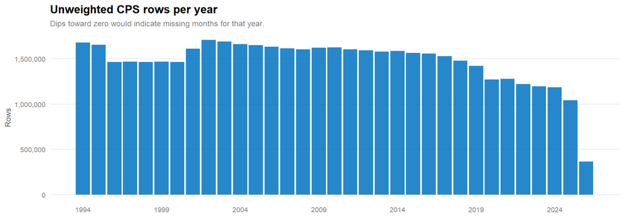

```r
yearly <- cps[, .(rows = .N), by = YEAR][order(YEAR)]
ggplot(yearly, aes(x = YEAR, y = rows)) +
  geom_col(fill = jco[1], alpha = 0.85) +
  scale_y_continuous(labels = label_comma()) +
  scale_x_continuous(breaks = seq(1994, max(yearly$YEAR), 5)) +
  labs(title = "Unweighted CPS rows per year",
       subtitle = "Dips toward zero would indicate missing months for that year.",
       x = NULL, y = "Rows")
```